# 黑櫻桃樹材積：複迴歸與 Box-Cox 分析

# 資料概況與探索

## Code 1：讀取資料與摘要

```r
d<-read.csv(params$data_file,check.names=FALSE)
summary(d)
```

```
##      Girth           Height       Volume
##  Min.   : 8.30   Min.   :63   Min.   :10.20
##  1st Qu.:11.05   1st Qu.:72   1st Qu.:19.40
##  Median :12.90   Median :76   Median :24.20
##  Mean   :13.25   Mean   :76   Mean   :30.17
##  3rd Qu.:15.25   3rd Qu.:80   3rd Qu.:37.30
##  Max.   :20.60   Max.   :87   Max.   :77.00
```

```r
colSums(is.na(d))
```

```
##  Girth Height Volume
##      0      0      0
```

```r
tools::md5sum(params$data_file)
```

```
##                          trees.csv
## "5657dc57f66727ab03b6b8798a347ebe"
```

**本段結果解釋：** 本段呈現每個欄位的摘要、缺失數及資料雜湊。先確認觀測單位、欄位意義與特殊遺失碼，再選擇分析變數；不得直接刪除缺失觀測或把識別碼當作解釋變數。共31棵黑櫻桃樹。Girth實為直徑（英吋）、Height為樹高（英尺）、Volume為材積（立方英尺）。沒有遺失、無限值或常數欄，未刪除任何觀測。

## Code 2：所有數值變數的兩兩散佈圖

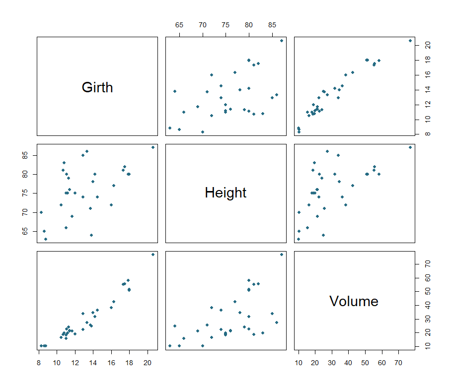

```r
numeric_names<-names(d)[vapply(d,is.numeric,logical(1))]
if(length(numeric_names)>=2) pairs(d[numeric_names],pch=19,col="#256B83")
```

```r
if(length(numeric_names)==1) hist(d[[numeric_names]],main=numeric_names,xlab=numeric_names)
names(d)[!vapply(d,is.numeric,logical(1))]
```

```
## character(0)
```

**本段結果解釋：** 散佈圖顯示數值變數的兩兩關係，非數值欄位另列。Girth與Volume呈強烈正向且略彎曲的關係；Height與其餘變數呈較分散的正向趨勢。

# 選定X與Y後的VIF與模型確認

## Code 3：設計矩陣VIF（不提前配適Y）

```r
design_check<-vif_design(d,y,xs,degrees=degrees,center=params$center_polynomial,
 centers=centers,selection_confirmed=TRUE)
```

```
## $model_type
## [1] "multiple regression"
##
## $formula
## Volume ~ Girth + Height
## <environment: 0x000001a5ec030cf0>
##
## $degrees
##  Girth Height
##      1      1
##
## $centers
## named numeric(0)
##
## $full_rank
## [1] TRUE
##
##   design_column     VIF tolerance       recommendation
## 1         Girth 1.36921 0.7303482 No strong VIF signal
## 2        Height 1.36921 0.7303482 No strong VIF signal
## Column-level VIF (factor dummy columns separately), not term-level GVIF. Thresholds 5 and 10 are heuristics; do not auto-delete predictors.
```

```r
centers<-design_check$spec$centers
```

**本段結果解釋：** 已設定X：Girth, Height；Y：Volume；模型類型：multiple regression。公式為`Volume ~ Girth + Height`。

研究目的：探討 Girth、Height 與 Volume 間的關係。

- Girth：VIF=1.3692，tolerance=0.7303；未見強烈VIF共線性訊號。
- Height：VIF=1.3692，tolerance=0.7303；未見強烈VIF共線性訊號。

這是column層級VIF，factor的dummy分開列出，非GVIF。5及10為經驗提示，不據此自動刪X。多項式的高VIF可能來自次方項本身；解讀須依本次確認的模型階數、中心化及公式。

本段記錄已完成的變數角色、VIF及模型設計；多項式列出實際使用的階數與中心值。

# 模型配適

## Code 4：估計模型、係數與檢定

```r
stopifnot(length(y)==1,length(xs)>=1,all(c(y,xs)%in%names(d)),is.numeric(d[[y]]))
stopifnot(!anyNA(d[c(y,xs)]))
fit<-fit_model(d,y,xs,approved=TRUE,degrees=degrees,
 center=params$center_polynomial,centers=centers)
summary(fit)
```

```
##
## Call:
## lm(formula = spec$formula, data = d, na.action = na.fail, x = TRUE,
##     y = TRUE)
##
## Residuals:
##     Min      1Q  Median      3Q     Max
## -6.4065 -2.6493 -0.2876  2.2003  8.4847
##
## Coefficients:
##             Estimate Std. Error t value Pr(>|t|)
## (Intercept) -57.9877     8.6382  -6.713 2.75e-07 ***
## Girth         4.7082     0.2643  17.816  < 2e-16 ***
## Height        0.3393     0.1302   2.607   0.0145 *
## ---
## Signif. codes:  0 '***' 0.001 '**' 0.01 '*' 0.05 '.' 0.1 ' ' 1
##
## Residual standard error: 3.882 on 28 degrees of freedom
## Multiple R-squared:  0.948,  Adjusted R-squared:  0.9442
## F-statistic:   255 on 2 and 28 DF,  p-value: < 2.2e-16
```

```r
confint(fit)
```

```
##                    2.5 %      97.5 %
## (Intercept) -75.68226247 -40.2930554
## Girth         4.16683899   5.2494820
## Height        0.07264863   0.6058538
```

**本段結果解釋：** 使用公式 `Volume ~ Girth + Height`，樣本數為31。整體F=254.9723（自由度2、28），p=< 1e-04，拒絕虛無假設（所有斜率為零）。R²=0.9480，調整R²=0.9442，殘差標準差=3.8818。

- (Intercept)：估計值-57.9877，SE=8.6382，t=-6.7129，p=< 1e-04，95% CI=[-75.6823, -40.2931]；拒絕虛無假設（該係數為零）。
- Girth：估計值4.7082，SE=0.2643，t=17.8161，p=< 1e-04，95% CI=[4.1668, 5.2495]；拒絕虛無假設（該係數為零）。
- Height：估計值0.3393，SE=0.1302，t=2.6066，p=0.01449，95% CI=[0.0726, 0.6059]；拒絕虛無假設（該係數為零）。

控制樹高後，直徑增加1英吋對應材積條件平均增加4.7082立方英尺；控制直徑後，樹高增加1英尺對應材積條件平均增加0.3393立方英尺。截距超出資料範圍。關聯不代表因果。假設診斷前推論為暫定。

## Code 5：原始資料與配適結果比較

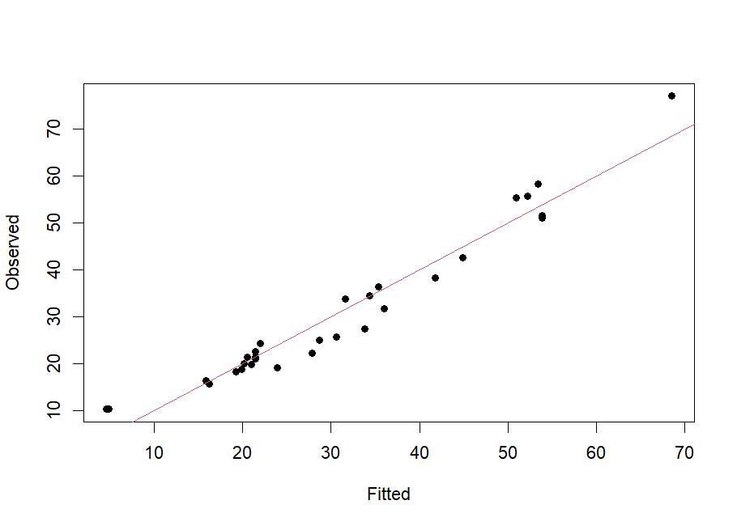

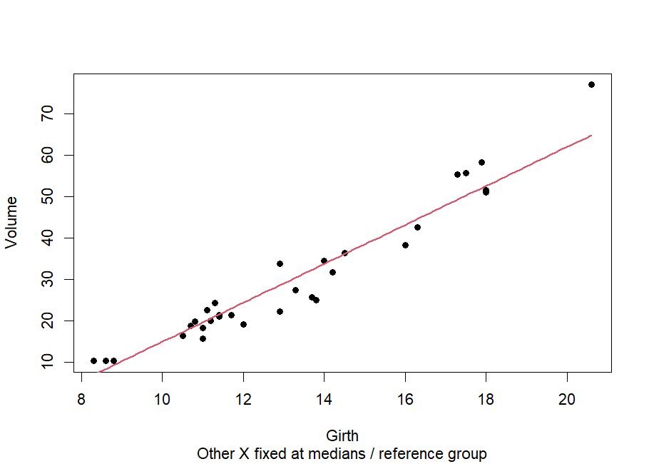

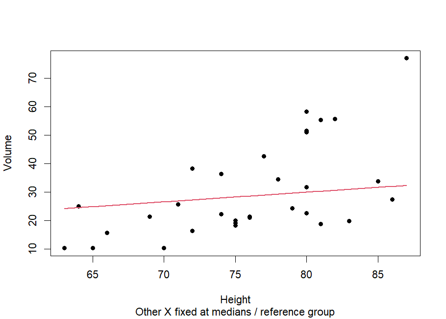

```r
fit_output(fit,d,y,xs,show_summary=FALSE)
```

**本段結果解釋：** 單一數值X比較原始點與直線／多項式曲線；多個X使用實際值對配適值圖及固定其他X的條件線／曲線，其他數值X固定中位數、factor固定參考組。原模型較大材積仍有偏離；條件線固定Height=76或Girth=12.9。不能把條件線當作所有原始點的邊際迴歸線。本圖用於檢視已配適模型與資料的偏離。

# 殘差分析

## Code 6：殘差圖與三項檢定

```r
diag_original<-diagnostics(fit,approved=TRUE,ordered=params$order_verified)
```

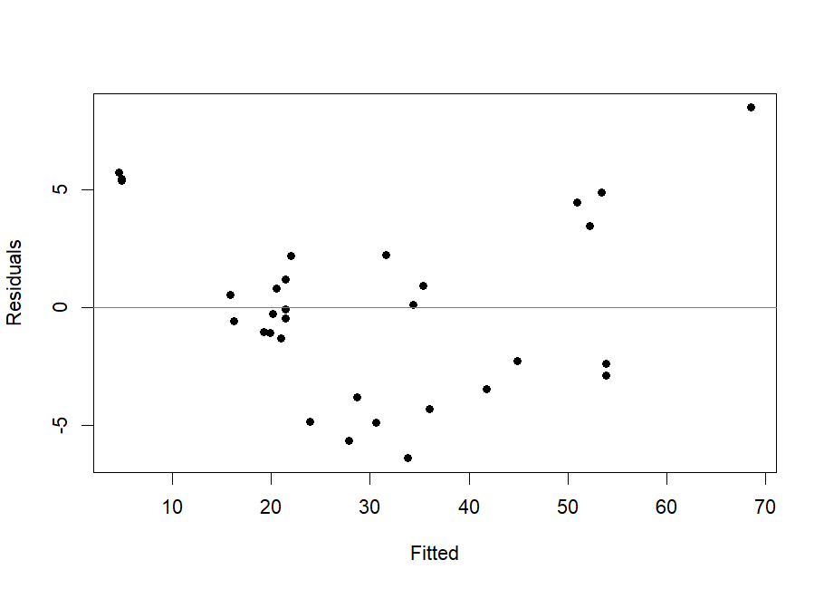

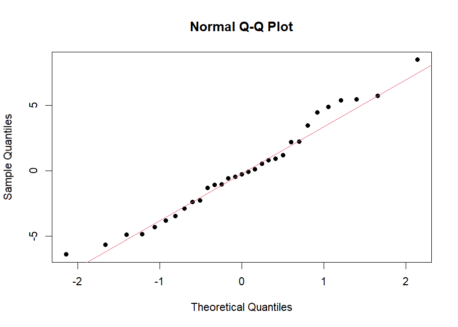

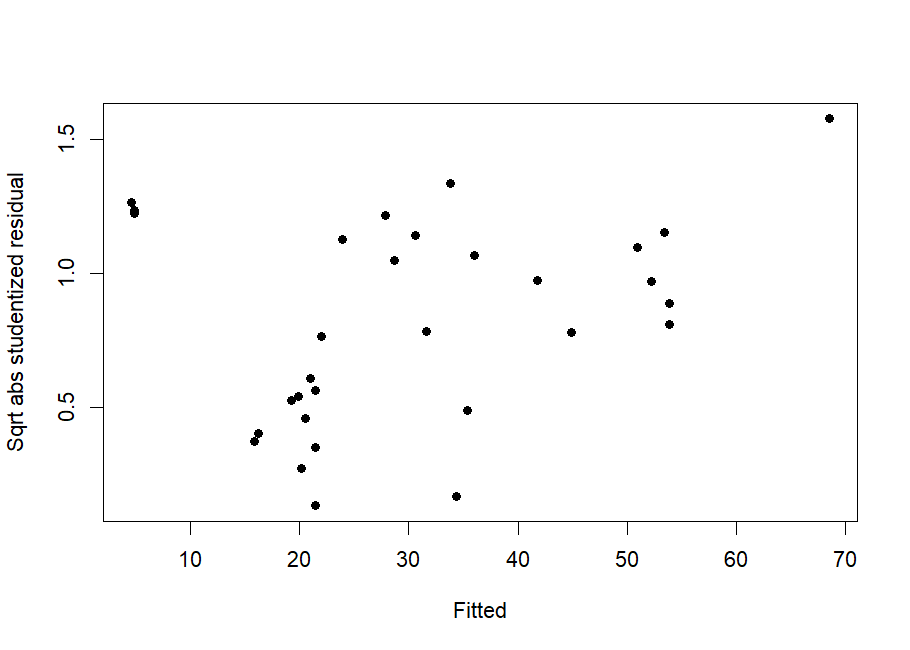

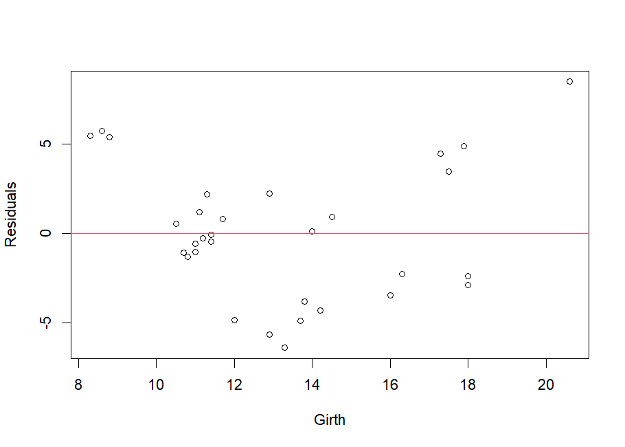

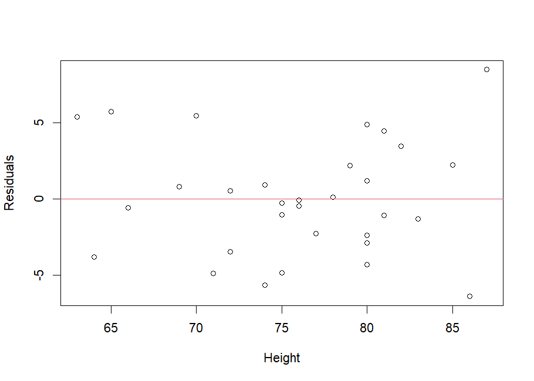

```
##
##  Shapiro-Wilk normality test
##
## data:  e
## W = 0.97431, p-value = 0.644
##
##
##  studentized Breusch-Pagan test
##
## data:  f
## BP = 2.4681, df = 2, p-value = 0.2911
##
##
##  Durbin-Watson test
##
## data:  f
## DW = 1.2665, p-value = 0.01834
## alternative hypothesis: true autocorrelation is not 0
##
## DW uses current data row order; no verified time/sampling order. Interpret as an order-dependent diagnostic, not proof of error independence.
```

**本段結果解釋：**

- Shapiro-Wilk：W=0.9743，p=0.644，沒有足夠證據拒絕虛無假設（常態性）。
- 學生化Breusch-Pagan：統計量=2.4681，p=0.2911，沒有足夠證據拒絕虛無假設（同方差）。
- Durbin-Watson：DW=1.2665，雙尾p=0.01834，拒絕虛無假設（一階誤差自相關為零）。

DW按目前資料row順序執行，尚未確認為時間或採樣順序；因此結果依賴排列，不能據此確認誤差獨立。

原模型殘差對配適值及Girth呈兩端偏正、中段偏負的彎曲跡象；Q-Q大致貼線，未見明確漏斗形。綜合建議探索Box-Cox。未拒絕不代表證明假設成立。

# Box-Cox：先看估計與圖，再決定轉換值

## Code 7：lambda估計、95%信賴區間與Box-Cox plot

```r
bc_profile<-boxcox_profile(fit,approved=TRUE)
```

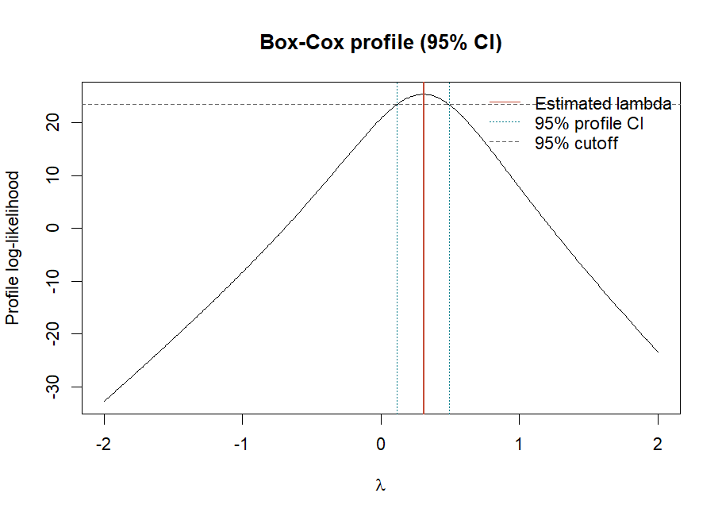

```
## $lambda_hat
## [1] 0.31
##
## $CI95
## [1] 0.1176399 0.4921738
```

**本段結果解釋：** lambda估計值為0.3100，95% profile likelihood CI為[0.1176, 0.4922]（由固定網格與端點線性內插近似）。圖中實線標示估計值、垂直虛線標示CI，水平線為95%門檻。

估計值與區間描述目前模型下的Box-Cox profile likelihood；實際使用的lambda於已完成的轉換結果中另外記錄。

# Box-Cox轉換與轉換後診斷

## Code 8：使用選定lambda轉換並重新配適

```r
bc<-transform_model(fit,d,y,xs,approved=TRUE,
 lambda=params$boxcox_lambda,profile=bc_profile)
```

```
## $lambda_hat
## [1] 0.31
##
## $CI95
## [1] 0.1176399 0.4921738
##
## $lambda_used
## [1] 0.31
##
## $chosen_by
## [1] "estimated"
```

```r
summary(bc$fit)
```

```
##
## Call:
## lm(formula = spec$formula, data = d, na.action = na.fail, x = TRUE,
##     y = TRUE)
##
## Residuals:
##      Min       1Q   Median       3Q      Max
## -0.43760 -0.14185 -0.01797  0.19188  0.37596
##
## Coefficients:
##              Estimate Std. Error t value Pr(>|t|)
## (Intercept) -2.848296   0.511617  -5.567 5.90e-06 ***
## Girth        0.419402   0.015652  26.796  < 2e-16 ***
## Height       0.040513   0.007708   5.256 1.38e-05 ***
## ---
## Signif. codes:  0 '***' 0.001 '**' 0.01 '*' 0.05 '.' 0.1 ' ' 1
##
## Residual standard error: 0.2299 on 28 degrees of freedom
## Multiple R-squared:  0.9776, Adjusted R-squared:  0.976
## F-statistic: 610.6 on 2 and 28 DF,  p-value: < 2.2e-16
```

```r
confint(bc$fit)
```

```
##                   2.5 %      97.5 %
## (Intercept) -3.89629486 -1.80029658
## Girth        0.38734147  0.45146322
## Height       0.02472245  0.05630262
```

**本段結果解釋：** lambda估計值0.3100；本次實際使用0.3100，來源為估計值（預設）。lambda=0採log(Y)，其餘採(Y^lambda−1)/lambda；若指定值在95%CI之外須如實註明，不自行改回估計值。

轉換後R²=0.9776，殘差標準差=0.2299，兩者均屬轉換尺度，不直接用來與原尺度比較優劣。係數與CI屬轉換尺度；控制另一X後，直徑與樹高皆呈顯著正向關聯，不能直接解讀為原始材積增加量。反轉換不自動等於無偏平均。

## Code 9：轉換後配適圖與殘差重檢

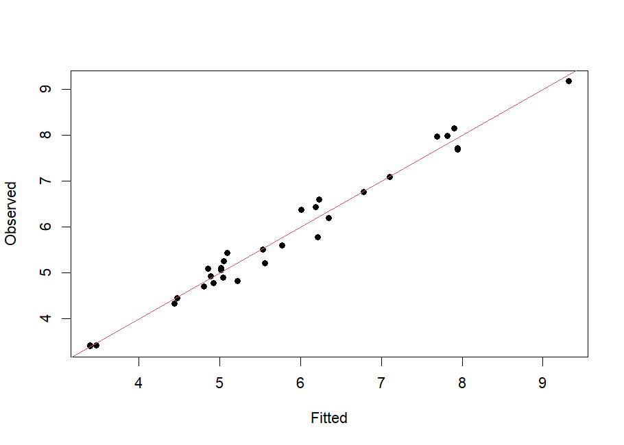

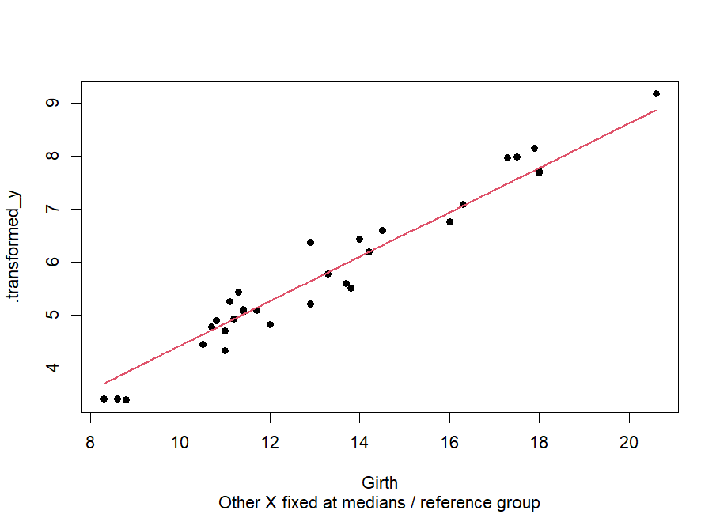

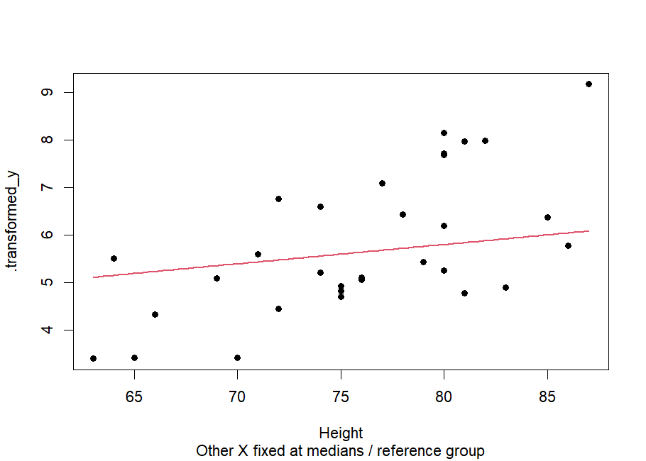

```r
fit_output(bc$fit,bc$data,".transformed_y",xs,show_summary=FALSE)
```

```r
diag_transformed<-diagnostics(bc$fit,approved=TRUE,ordered=params$order_verified)
```

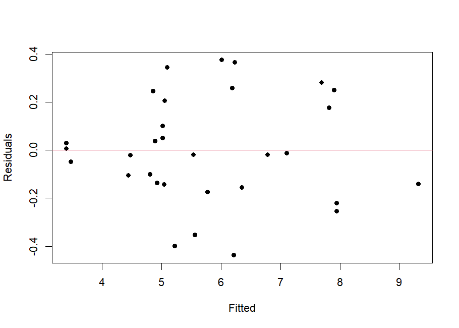

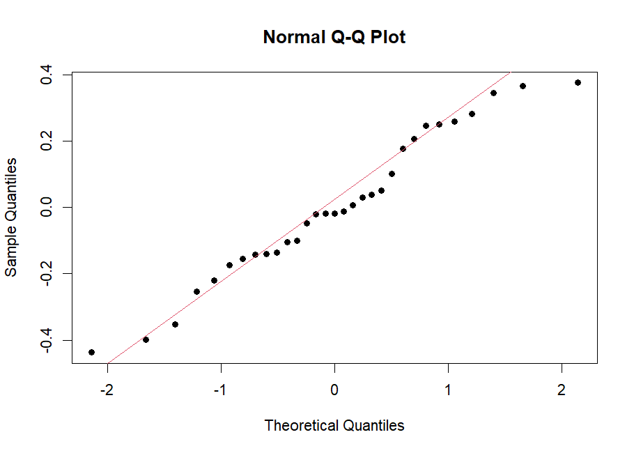

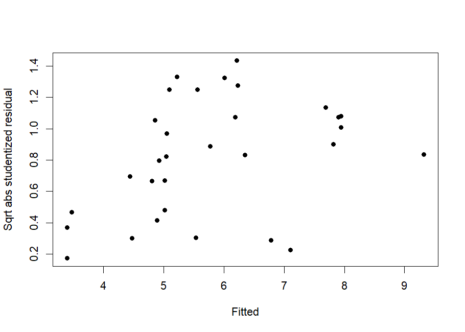

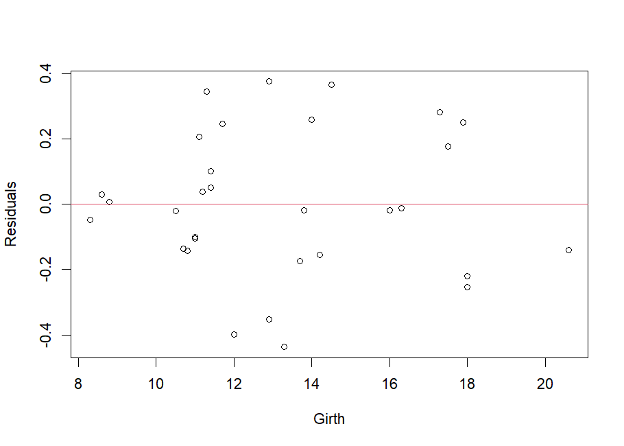

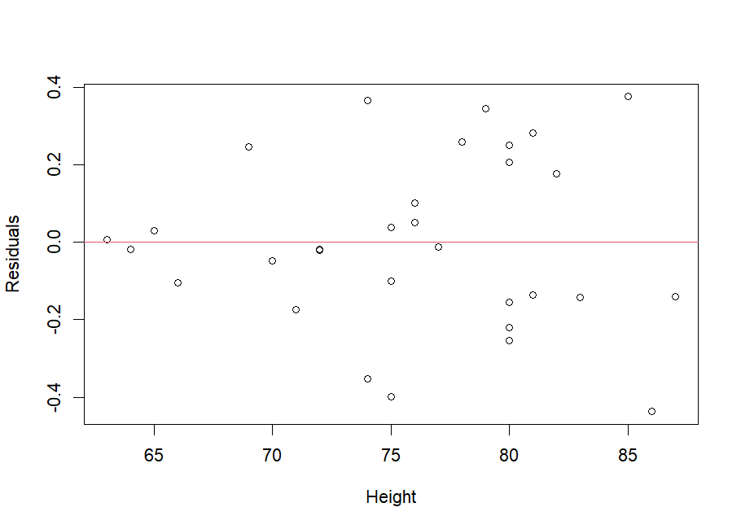

```
##
##  Shapiro-Wilk normality test
##
## data:  e
## W = 0.96813, p-value = 0.4692
##
##
##  studentized Breusch-Pagan test
##
## data:  f
## BP = 5.3587, df = 2, p-value = 0.06861
##
##
##  Durbin-Watson test
##
## data:  f
## DW = 2.0668, p-value = 0.9572
## alternative hypothesis: true autocorrelation is not 0
##
## DW uses current data row order; no verified time/sampling order. Interpret as an order-dependent diagnostic, not proof of error independence.
```

**本段結果解釋：** 轉換後實際與配適值較貼近對角線；殘差彎曲減弱，Q-Q大致貼線，散布仍不完全均勻。條件線固定Height=76或Girth=12.9。

- Shapiro-Wilk：p=0.4692，沒有足夠證據拒絕虛無假設（常態性）。
- Breusch-Pagan：p=0.06861，沒有足夠證據拒絕虛無假設（同方差）。
- Durbin-Watson：DW=2.0668，p=0.9572，沒有足夠證據拒絕虛無假設（一階誤差自相關為零）。

DW沿用目前row順序，無已確認時間意義；轉換不保證消除相依。

殘差系統性彎曲減弱。未拒絕不代表證明假設成立；DW未確認時間順序，一般lm推論未包含lambda估計不確定性。

# 離群與影響點

## Code 10：離群與影響指標

```r
final_fit<-if(params$approve_boxcox) bc$fit else fit
flags<-influence_output(final_fit,approved=TRUE)
```

```
##    row_id  leverage    internal    external         cook      dffits
## 17     17 0.1313092  1.75448713  1.82617581 0.1550989649  0.70999857
## 18     18 0.1434615 -2.05658377 -2.19184311 0.2361348558 -0.89702333
## 20     20 0.2112366 -0.09353384 -0.09186276 0.0007809779 -0.04753908
## 31     31 0.2270585 -0.69741923 -0.69087908 0.0476274991 -0.37445328
##    max_abs_dfbetas high_leverage internal_flag outlier_bonferroni cook_over_1
## 17      0.61537109         FALSE         FALSE              FALSE       FALSE
## 18      0.78972803         FALSE         FALSE              FALSE       FALSE
## 20      0.04363284          TRUE         FALSE              FALSE       FALSE
## 31      0.24279137          TRUE         FALSE              FALSE       FALSE
##    cook_screen dffits_screen dfbetas_screen
## 17        TRUE          TRUE           TRUE
## 18        TRUE          TRUE           TRUE
## 20       FALSE         FALSE          FALSE
## 31       FALSE         FALSE          FALSE
##                                   flag_reason
## 17 cook_screen, dffits_screen, dfbetas_screen
## 18 cook_screen, dffits_screen, dfbetas_screen
## 20                              high_leverage
## 31                              high_leverage
## DFBETAS for flagged samples only:
##    (Intercept)       Girth      Height
## 17  -0.5329790 -0.35348935  0.61537109
## 18   0.7062269  0.40401251 -0.78972803
## 20  -0.0411297 -0.02549449  0.04363284
## 31   0.1850255 -0.24279137 -0.08559496
```

**本段結果解釋：** 本次診斷轉換後模型。

共4個樣本被至少一項門檻標記，僅呈現這些樣本：17, 18, 20, 31。 各樣本flag_reason列出觸發原因；表內包含其診斷值，DFBETAS亦只列被標記樣本。

門檻：高槓桿h>2p/n；內學生化殘差絕對值>3；外學生化殘差採qt(1-alpha/(2n),n-p-1)的Bonferroni校正；Cook D>1與補充4/n；DFFITS絕對值>2sqrt(p/n)；DFBETAS絕對值>2/sqrt(n)，p含截距。第17、18筆觸發Cook補充、DFFITS與DFBETAS篩檢；第20、31筆為高槓桿。沒有Bonferroni反應離群或Cook D>1。篩檢不代表資料錯誤；未刪點。

# 確認紀錄

使用者指定Volume為Y，Girth、Height為X。模型選擇：「一次複迴歸」；配適、殘差分析與Box-Cox確認均回答「是」；lambda選擇：「使用估計值 λ＝0.31 進行轉換」；轉換後影響檢測回答「是」。所有階段完成，未確認時間或採樣順序。

# 重現資訊與方法來源

方法依Program_1.pdf、Program_2.pdf及Montgomery、Peck、Vining（2012）Introduction to Linear Regression Analysis，第5版第2–6章。完整公式與教材勘誤見methods.md。教材PDF未隨附件提供，本次依skill方法文件實作。